# Supplemental Materials

### 3.3.3 Compositional RDA plots

#### Explained Variance in RDA’s

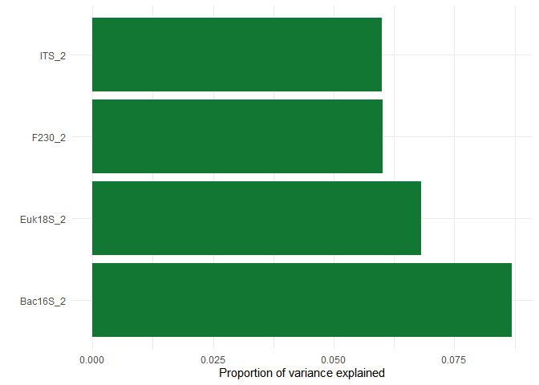

Figure 3.14: Proportion of variance explained by season. Model names are described as the targeted gene (16S, 18S, ITS, or, F230), summarization level (ESV, genus, or functional groupings) and the soil layers represented in the rda model (MIN = 0-10 cm depth mineral soil samples, LFH = L, FH, or LFH samples).

#### Bacterial (16S)

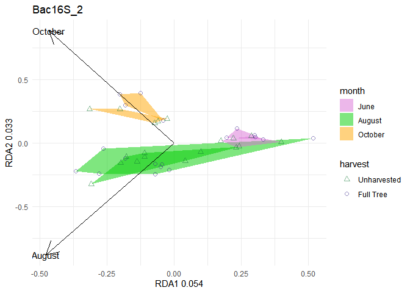

#### Fungal (ITS)

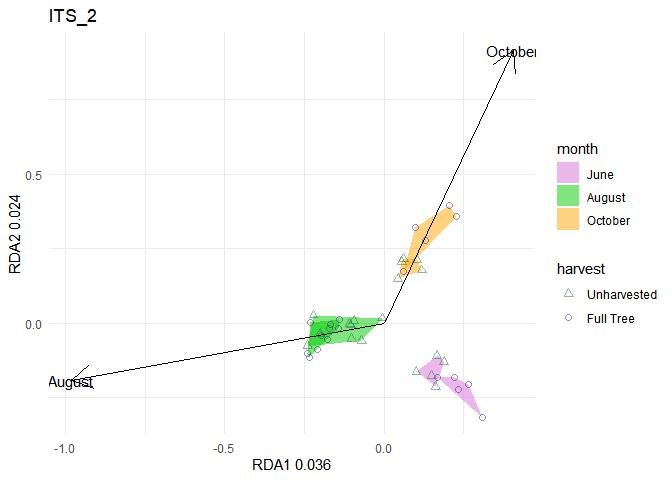

#### Arthropods (F230)

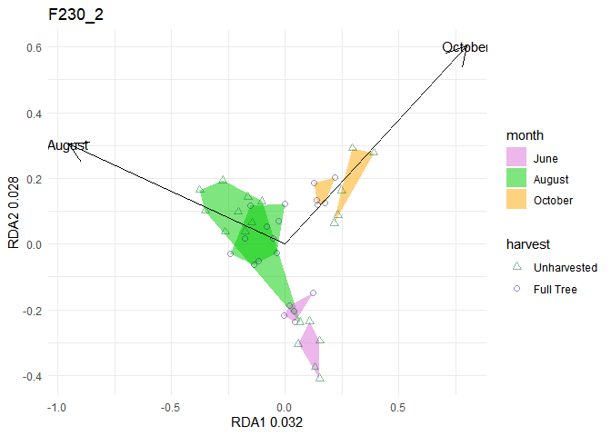

#### Eukaryotes (18S)

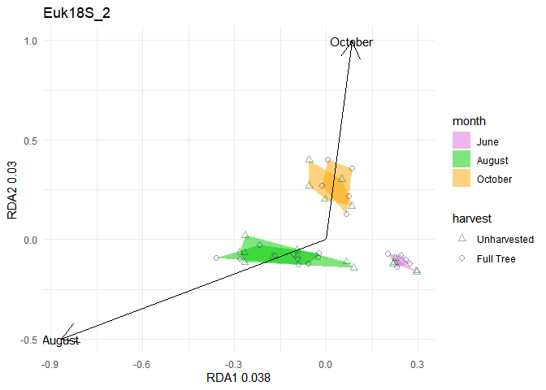

Partial RDA with month as constraining variables, and treatment as control variables showed that seasonal variation, in general, represented a small amount of community composition variance (less than 10%) for any metabarcoding target. There were some indications that there were larger seasonal differences introduced by harvesting in arthropod and eukaryotic communities. The distances along the axes associated with the month gradients were slightly larger in harvested eukaryote communities and, slightly smaller in the harvested arthropod communities compared to unharvested treatments (Supplemental Materials 2.3.3).

### 3.3.4 Differences in specific organisms

#### Bac16S

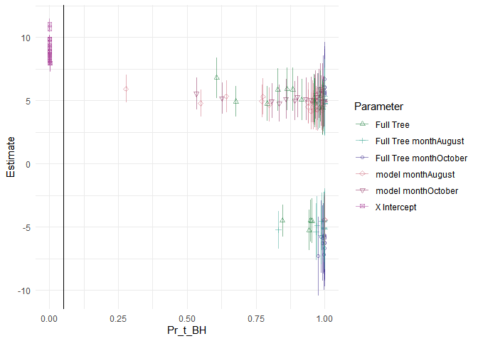

Graph shows 20 most significant organisms for each parameter.

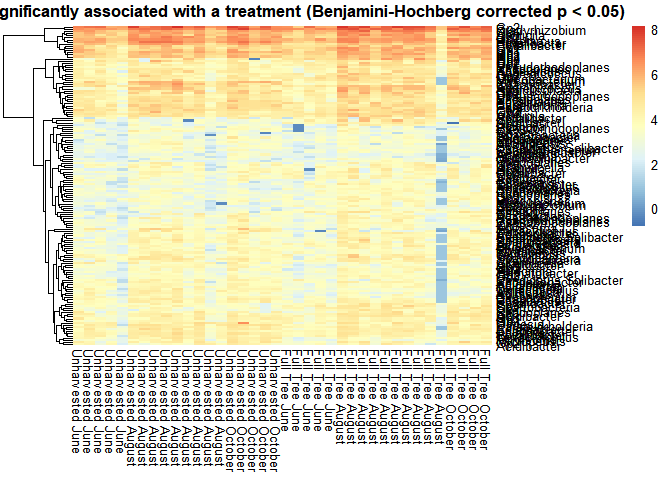

#### ITS

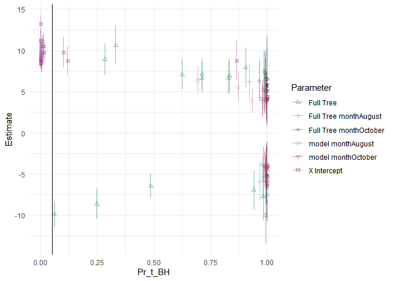

Graph shows 20 most significant organisms for each parameter.

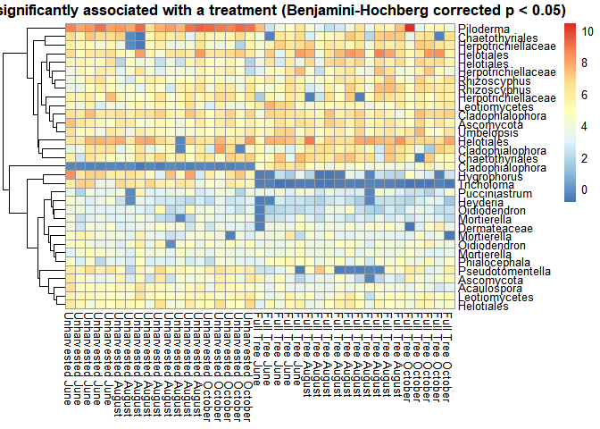

#### F230

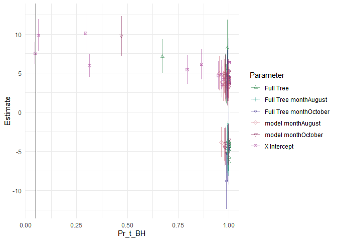

Graph shows 20 most significant organisms for each parameter.

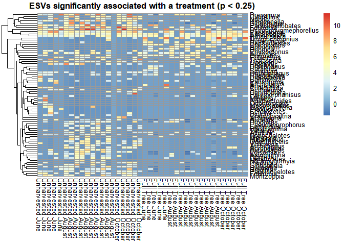